# Chapter 11: Forecasting hierarchical and grouped time series

maurogm 2023-08-25

- Link
- Hierarchical and grouped time series
  - Example: Australian tourism hierarchy (jerarquía anidada)
  - Example: Australian prison population (jerarquía cruzada)
  - Mixed hierarchical and grouped structure
- Single level approaches
  - Bottom-up forecasts
  - Top-down forecasts
  - Middle-out forecasts
- Ejemplos del uso de Min-trace
  - Example: Forecasting Australian domestic tourism
- Reconciled distributional forecasts
  - Example: Forecasting Australian prison population

## Hierarchical and grouped time series

### Example: Australian tourism hierarchy (jerarquía anidada)

Para mostrar el uso de series temporales jerárquicas y agrupadas, empezamos con datos de turismo australiano agrupados geográficamente por región y estado:

```r
tourism <- tsibble::tourism |>
  mutate(State = recode(State,
    `New South Wales` = "NSW",
    `Northern Territory` = "NT",
    `Queensland` = "QLD",
    `South Australia` = "SA",
    `Tasmania` = "TAS",
    `Victoria` = "VIC",
    `Western Australia` = "WA"
  ))
tourism %>% head()
```

```
## # A tsibble: 6 x 5 [1Q]
## # Key:       Region, State, Purpose [1]
##   Quarter Region   State Purpose  Trips
##     <qtr> <chr>    <chr> <chr>    <dbl>
## 1 1998 Q1 Adelaide SA    Business  135.
## 2 1998 Q2 Adelaide SA    Business  110.
## 3 1998 Q3 Adelaide SA    Business  166.
## 4 1998 Q4 Adelaide SA    Business  127.
## 5 1999 Q1 Adelaide SA    Business  137.
## 6 1999 Q2 Adelaide SA    Business  200.
```

La función `aggregate_key` nos permite crear una jerarquía. La sintaxis `parent/child` se usa para especificar una jerarquía anidada, en este caso creando series nuevas que agrupan los datos a nivel estatal y nacional:

```r
tourism_hts <- tourism |>
  aggregate_key(State / Region, Trips = sum(Trips))
tourism_hts
```

```
## # A tsibble: 6,800 x 4 [1Q]
## # Key:       State, Region [85]
##    Quarter State        Region        Trips
##      <qtr> <chr*>       <chr*>        <dbl>
##  1 1998 Q1 <aggregated> <aggregated> 23182.
##  2 1998 Q2 <aggregated> <aggregated> 20323.
##  3 1998 Q3 <aggregated> <aggregated> 19827.
##  4 1998 Q4 <aggregated> <aggregated> 20830.
##  5 1999 Q1 <aggregated> <aggregated> 22087.
##  6 1999 Q2 <aggregated> <aggregated> 21458.
##  7 1999 Q3 <aggregated> <aggregated> 19914.
##  8 1999 Q4 <aggregated> <aggregated> 20028.
##  9 2000 Q1 <aggregated> <aggregated> 22339.
## 10 2000 Q2 <aggregated> <aggregated> 19941.
## # … with 6,790 more rows
```

```r
tourism_hts %>%
  tsibble::key_data() %>%
  print(n = 100)
```

```
## # A tibble: 85 × 3
##    State        Region                                .rows
##    <chr*>       <chr*>                          <list<int>>
##  1 ACT          Canberra                               [80]
##  2 ACT          <aggregated>                           [80]
##  3 NSW          Blue Mountains                         [80]
##  4 NSW          Capital Country                        [80]
##  5 NSW          Central Coast                          [80]
##  6 NSW          Central NSW                            [80]
##  7 NSW          Hunter                                 [80]
##  8 NSW          New England North West                 [80]
##  9 NSW          North Coast NSW                        [80]
## 10 NSW          Outback NSW                            [80]
## 11 NSW          Riverina                               [80]
## 12 NSW          Snowy Mountains                        [80]
```

[output cut: 73 more lines]

### Example: Australian prison population (jerarquía cruzada)

Cuando las dimensiones a agrupar no son jerárquicas, se puede usar la sintaxis `Group1 * Group2` para especificar una estructura de grupos cruzados. Por ejemplo, los datos de población carcelaria australiana se pueden agrupar por género, status legal y estado:

```r
prison <- readr::read_csv("https://OTexts.com/fpp3/extrafiles/prison_population.csv") |>
  mutate(Quarter = yearquarter(Date)) |>
  select(-Date) |>
  as_tsibble(
    key = c(Gender, Legal, State, Indigenous),
    index = Quarter
  ) |>
  relocate(Quarter)

prison_gts <- prison |>
  aggregate_key(Gender * Legal * State, Count = sum(Count) / 1e3)
```

La función `is_aggregated` es muy conveniente para filtrar datos agregados durante un análisis exploratorio:

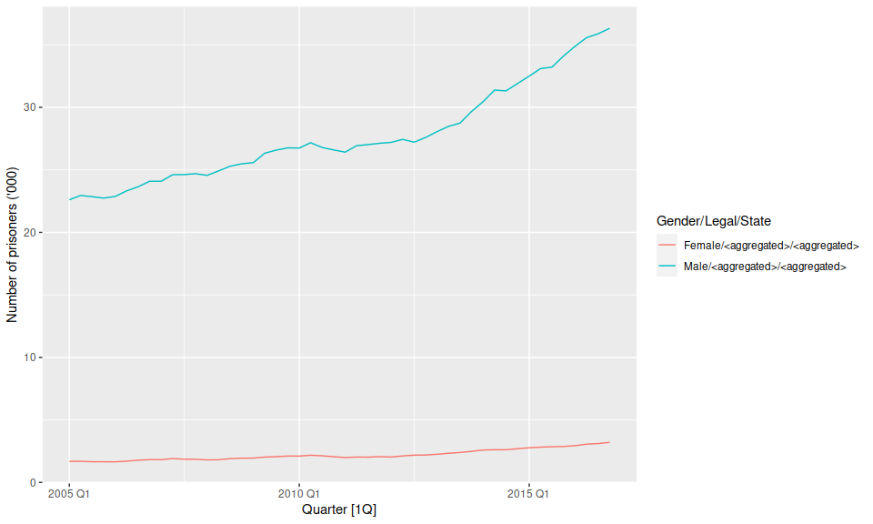

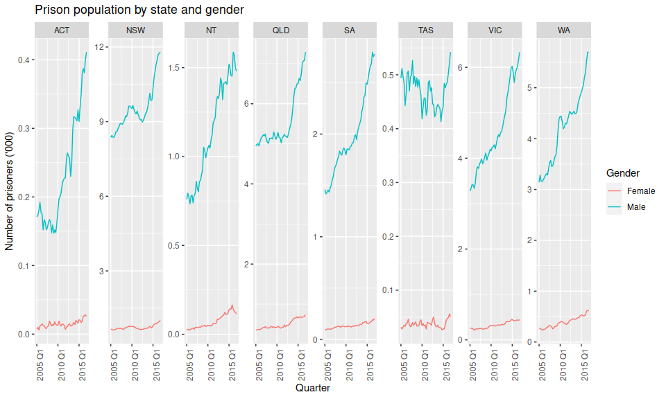

```r
prison_gts |>
  filter(
    !is_aggregated(Gender), is_aggregated(Legal),
    is_aggregated(State)
  ) |>
  autoplot(Count) +
  labs(y = "Number of prisoners ('000)")

prison_gts |>
  filter(
    !is_aggregated(Gender), !is_aggregated(Legal),
    !is_aggregated(State)
  ) |>
  mutate(Gender = as.character(Gender)) |>
  ggplot(aes(
    x = Quarter, y = Count,
    group = Gender, colour = Gender
  )) +
  stat_summary(fun = sum, geom = "line") +
  labs(
    title = "Prison population by state and gender",
    y = "Number of prisoners ('000)"
  ) +
  facet_wrap(~ as.character(State),
    nrow = 1, scales = "free_y"
  ) +
  theme(axis.text.x = element_text(angle = 90, hjust = 1))
```

### Mixed hierarchical and grouped structure

La sintaxis de jararquías anidadas `Parent/Child` y de grupos cruzados `Gropo1 * Grupo2` se pueden combinar para crear estructuras mixtas:

```r
tourism_full <- tourism |>
  aggregate_key((State / Region) * Purpose, Trips = sum(Trips))
tourism_full %>% filter(!is_aggregated(Purpose), !is_aggregated(State))
```

```
## # A tsibble: 26,880 x 5 [1Q]
## # Key:       State, Purpose, Region [336]
##    Quarter State  Purpose  Region        Trips
##      <qtr> <chr*> <chr*>   <chr*>        <dbl>
##  1 1998 Q1 ACT    Business <aggregated>  150.
##  2 1998 Q1 ACT    Holiday  <aggregated>  196.
##  3 1998 Q1 ACT    Other    <aggregated>   21.7
##  4 1998 Q1 ACT    Visiting <aggregated>  183.
##  5 1998 Q1 NSW    Business <aggregated> 1148.
##  6 1998 Q1 NSW    Holiday  <aggregated> 4033.
##  7 1998 Q1 NSW    Other    <aggregated>  262.
##  8 1998 Q1 NSW    Visiting <aggregated> 2597.
##  9 1998 Q1 NT     Business <aggregated>   91.6
## 10 1998 Q1 NT     Holiday  <aggregated>   59.8
## # … with 26,870 more rows
```

## Single level approaches

Vamos a usar los datos de turismo australiano para ilustrar estraegias de conciliación de forecasts de series temporales jerárquicas.

```r
tourism_states <- tourism |>
  aggregate_key(State, Trips = sum(Trips))
```

### Bottom-up forecasts

Si quisiéramos hacer una estrategia bottom-up a mano, deberíamos hacer un forecast para cada serie no-agrupada, y luego sumar los forecasts para cada grupo. Empezamos por hacer los forecasts para cada serie independiente:

```r
fcasts_state <- tourism_states |>
  filter(!is_aggregated(State)) |>
  model(ets = ETS(Trips)) |>
  forecast()
fcasts_state
```

```
## # A fable: 64 x 5 [1Q]
## # Key:     State, .model [8]
##    State  .model Quarter           Trips .mean
##    <chr*> <chr>    <qtr>          <dist> <dbl>
##  1 ACT    ets    2018 Q1    N(701, 7651)  701.
##  2 ACT    ets    2018 Q2    N(717, 8032)  717.
##  3 ACT    ets    2018 Q3    N(734, 8440)  734.
##  4 ACT    ets    2018 Q4    N(750, 8882)  750.
##  5 ACT    ets    2019 Q1    N(767, 9368)  767.
##  6 ACT    ets    2019 Q2    N(784, 9905)  784.
##  7 ACT    ets    2019 Q3   N(800, 10503)  800.
##  8 ACT    ets    2019 Q4   N(817, 11171)  817.
##  9 NSW    ets    2018 Q1  N(8886, 96984) 8886.
## 10 NSW    ets    2018 Q2 N(8311, 122362) 8311.
## # … with 54 more rows
```

Y construimos los forecasts generales agrupando los individuales:

```r
fcasts_national <- fcasts_state |>
  summarise(value = sum(Trips), .mean = mean(value))
fcasts_national
```

```
## # A tsibble: 8 x 3 [1Q]
##   Quarter             value  .mean
##     <qtr>            <dist>  <dbl>
## 1 2018 Q1  N(28925, 480068) 28925.
## 2 2018 Q2  N(26929, 509928) 26929.
## 3 2018 Q3  N(26267, 564670) 26267.
## 4 2018 Q4   N(27166, 7e+05) 27166.
## 5 2019 Q1  N(28991, 935854) 28991.
## 6 2019 Q2  N(26995, 894181) 26995.
## 7 2019 Q3  N(26333, 920929) 26333.
## 8 2019 Q4 N(27232, 1092272) 27232.
```

Por suerte no hace falta hacerlo a mano. La función `reconcile` ofrece una API general para conciliar forecasts, donde sólo debemos especificar la estrategia de reconciliación:

```r
reconciled_models <- tourism_states |>
  model(ets = ETS(Trips)) |>
  reconcile(bu = bottom_up(ets))
```

El paso de `recocile` va entre el modelado y el forecasting, y devuelve tanto los modelos originales como los conciliados. El modelo conciliado es una columna de modelos más, y a partir de ahí se puede forecastear normalmente:

```r
reconciled_models |>
  forecast()
```

```
## # A fable: 144 x 5 [1Q]
## # Key:     State, .model [18]
##    State  .model Quarter         Trips .mean
##    <chr*> <chr>    <qtr>        <dist> <dbl>
##  1 ACT    ets    2018 Q1  N(701, 7651)  701.
##  2 ACT    ets    2018 Q2  N(717, 8032)  717.
##  3 ACT    ets    2018 Q3  N(734, 8440)  734.
##  4 ACT    ets    2018 Q4  N(750, 8882)  750.
##  5 ACT    ets    2019 Q1  N(767, 9368)  767.
##  6 ACT    ets    2019 Q2  N(784, 9905)  784.
##  7 ACT    ets    2019 Q3 N(800, 10503)  800.
##  8 ACT    ets    2019 Q4 N(817, 11171)  817.
##  9 ACT    bu     2018 Q1  N(701, 7651)  701.
## 10 ACT    bu     2018 Q2  N(717, 8032)  717.
## # … with 134 more rows
```

### Top-down forecasts

Los forecasts top-down se pueden generar usando `top_down()` dentro de la función `reconcile()`:

```r
individual_models <- tourism_states |>
  model(ets = ETS(Trips))
individual_models %>%
  reconcile(td = top_down(ets)) %>%
  forecast()
```

```
## # A fable: 144 x 5 [1Q]
## # Key:     State, .model [18]
##    State  .model Quarter         Trips .mean
##    <chr*> <chr>    <qtr>        <dist> <dbl>
##  1 ACT    ets    2018 Q1  N(701, 7651)  701.
##  2 ACT    ets    2018 Q2  N(717, 8032)  717.
##  3 ACT    ets    2018 Q3  N(734, 8440)  734.
##  4 ACT    ets    2018 Q4  N(750, 8882)  750.
##  5 ACT    ets    2019 Q1  N(767, 9368)  767.
##  6 ACT    ets    2019 Q2  N(784, 9905)  784.
##  7 ACT    ets    2019 Q3 N(800, 10503)  800.
##  8 ACT    ets    2019 Q4 N(817, 11171)  817.
##  9 ACT    td     2018 Q1   N(704, 411)  704.
## 10 ACT    td     2018 Q2   N(740, 618)  740.
## # … with 134 more rows
```

Los distintos criterios para hacer conciliaciones top-down se pueden especificar con el argumento `method` de `top_down()`. El mismo puede aceptar los valores `average_proportions`, `proportion_averages` y `forecast_proportions` (el default):

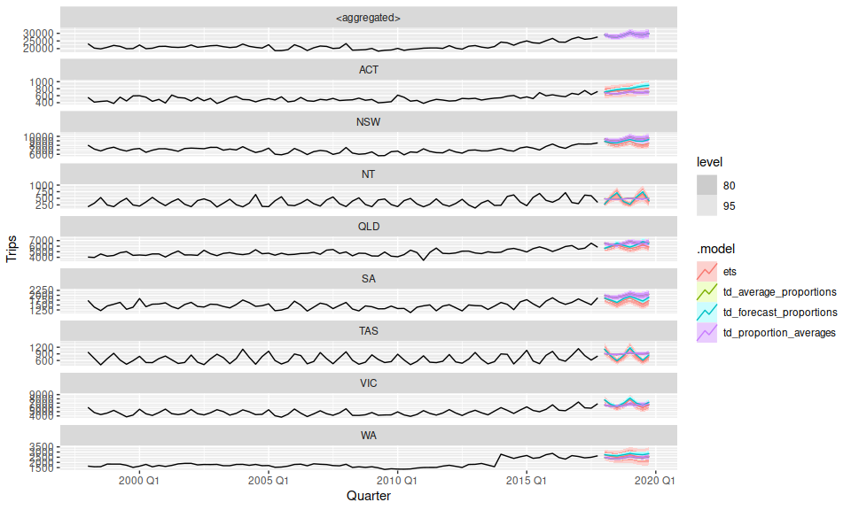

```r
top_down_reconciliations <- individual_models %>%
  reconcile(
    td_average_proportions = top_down(ets, method = "average_proportions"),
    td_proportion_averages = top_down(ets, method = "proportion_averages"),
    td_forecast_proportions = top_down(ets, method = "forecast_proportions")
  )
top_down_reconciliations %>%
  forecast() %>%
  autoplot(tourism_states)
```

Es interesante como `forecast_proportions` es el único que conserva algo de la forma de las series originales. Particularmente notable en el caso de `NT`, donde hasta los intervalos de confianza son claramente cualquier cosa.

### Middle-out forecasts

las conciliaciones middle-out se pueden generar usando `middle_out()`, especificando el nivel a usar como base con el argumento `split`. El default, `split = 1` usa el nivel inmediatamente debajo del Total como base:

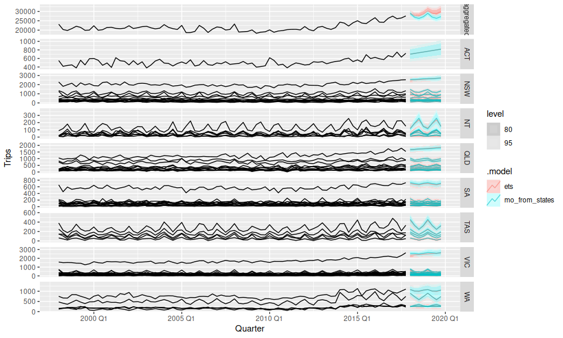

```r
tourism_states_region <- tourism |>
  aggregate_key(State / Region, Trips = sum(Trips))

initial_models <- tourism_states_region %>%
  model(ets = ETS(Trips))

reconciled_models <- initial_models %>%
  reconcile(
    mo_from_states = middle_out(ets)
  )
reconciled_models %>%
  forecast() %>%
  filter(!is_aggregated(Region) | is_aggregated(State)) %>%
  autoplot(tourism_states_region, alpha = 0.6) +
  facet_grid(State ~ ., scales = "free_y")
```

## Ejemplos del uso de Min-trace

### Example: Forecasting Australian domestic tourism

Veamos como funciona la conciliación en un caso en que la jerarquía tiene tanto Padre/Hijo como grupos cruzados.

```r
tourism_full <- tourism |>
  aggregate_key((State / Region) * Purpose, Trips = sum(Trips))

fit <- tourism_full |>
  filter(year(Quarter) <= 2015) |>
  model(base = ETS(Trips)) |>
  reconcile(
    bu = bottom_up(base),
    ols = min_trace(base, method = "ols"),
    mint = min_trace(base, method = "mint_shrink")
  )

fc <- fit |> forecast(h = "2 years")
```

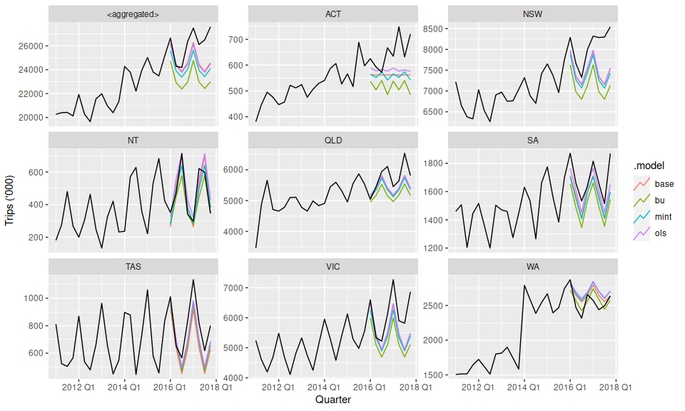

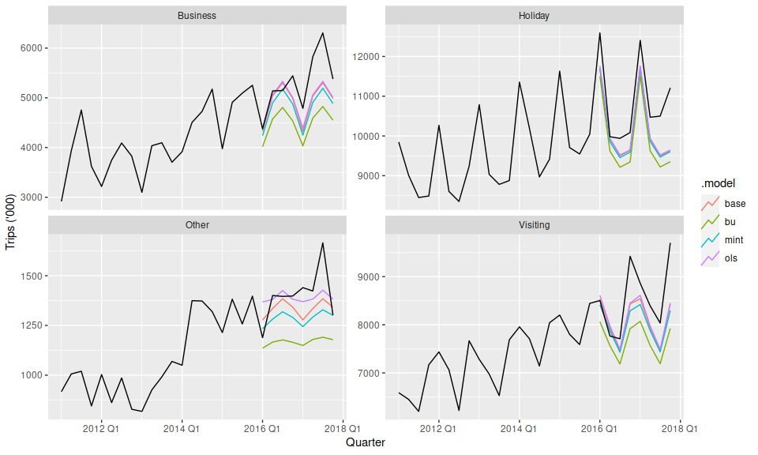

```r
fc |>
  filter(is_aggregated(Region), is_aggregated(Purpose)) |>
  autoplot(
    tourism_full |> filter(year(Quarter) >= 2011),
    level = NULL
  ) +
  labs(y = "Trips ('000)") +
  facet_wrap(vars(State), scales = "free_y")

fc |>
  filter(is_aggregated(State), !is_aggregated(Purpose)) |>
  autoplot(
    tourism_full |> filter(year(Quarter) >= 2011),
    level = NULL
  ) +
  labs(y = "Trips ('000)") +
  facet_wrap(vars(Purpose), scales = "free_y")
```

Al medir la performance hay que tener cuidado, dado que muchas métricas, como el RMSE, dependen de la escala de los datos, y por lo tanto no son comparables entre distintos niveles de agregación. En esos casos se puede filtrar antes de calcular las métricas, y repetir para cada nivel que se quiera estudiar:

```r
fc |>
  filter(is_aggregated(State), is_aggregated(Purpose)) |>
  accuracy(
    data = tourism_full,
    measures = list(rmse = RMSE, mase = MASE)
  ) |>
  group_by(.model) |>
  summarise(rmse = mean(rmse), mase = mean(mase))
```

```
## # A tibble: 4 × 3
##   .model  rmse  mase
##   <chr>  <dbl> <dbl>
## 1 base   1721.  1.53
## 2 bu     3071.  3.17
## 3 mint   2158.  2.09
## 4 ols    1804.  1.63
```

## Reconciled distributional forecasts

### Example: Forecasting Australian prison population

Veamos en un nuevo ejemplo como se pueden hacer forecasts distribucionales conciliados. Volvemos al ejemplo de la población carcelaria australiana.

```r
fit <- prison_gts |>
  filter(year(Quarter) <= 2014) |>
  model(base = ETS(Count)) |>
  reconcile(
    bottom_up = bottom_up(base),
    MinT = min_trace(base, method = "mint_shrink")
  )
fc <- fit |> forecast(h = 8)
fc
```

```
## # A fable: 1,944 x 7 [1Q]
## # Key:     Gender, Legal, State, .model [243]
##    Gender Legal    State  .model    Quarter              Count   .mean
##    <chr*> <chr*>   <chr*> <chr>       <qtr>             <dist>   <dbl>
##  1 Female Remanded ACT    base      2015 Q1 N(0.0051, 2.8e-06) 0.00508
##  2 Female Remanded ACT    base      2015 Q2 N(0.0051, 4.3e-06) 0.00512
##  3 Female Remanded ACT    base      2015 Q3 N(0.0052, 6.1e-06) 0.00516
##  4 Female Remanded ACT    base      2015 Q4 N(0.0052, 8.3e-06) 0.00521
##  5 Female Remanded ACT    base      2016 Q1 N(0.0052, 1.1e-05) 0.00525
##  6 Female Remanded ACT    base      2016 Q2 N(0.0053, 1.4e-05) 0.00529
##  7 Female Remanded ACT    base      2016 Q3 N(0.0053, 1.7e-05) 0.00533
##  8 Female Remanded ACT    base      2016 Q4 N(0.0054, 2.1e-05) 0.00538
##  9 Female Remanded ACT    bottom_up 2015 Q1 N(0.0051, 2.8e-06) 0.00508
## 10 Female Remanded ACT    bottom_up 2015 Q2 N(0.0051, 4.3e-06) 0.00512
## # … with 1,934 more rows
```

Dado que no agregamos `bootstrap = TRUE` en el paso de `forecast()`, los errores base se asumen normales, y por lo tanto los forecasts conciliados también.

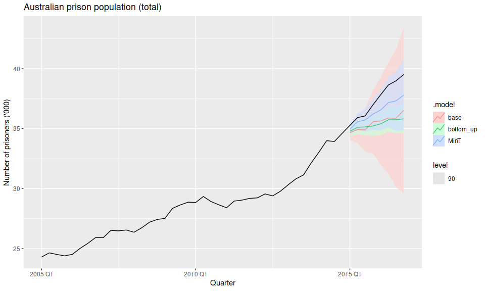

```r
fc |>
  filter(
    is_aggregated(State), is_aggregated(Gender),
    is_aggregated(Legal)
  ) |>
  autoplot(prison_gts, alpha = 0.7, level = 90) +
  labs(
    y = "Number of prisoners ('000)",
    title = "Australian prison population (total)"
  )
```

Los forecasts a nivel Estado también suelen ser mejores con min_trace, aunque hay varios casos en los que tendencias novedosas en el set de test quedan por fuera de lo forecasteado:

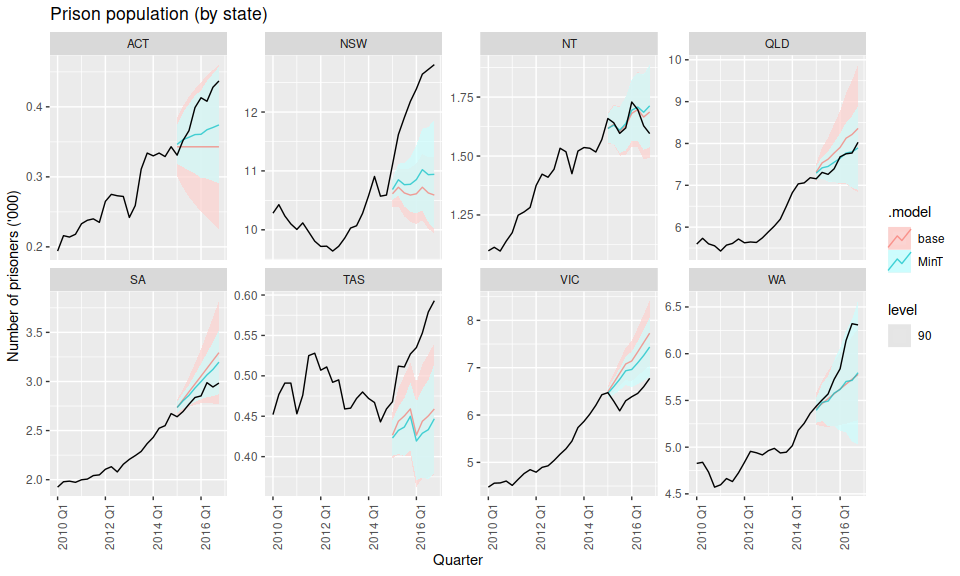

```r
fc |>
  filter(
    .model %in% c("base", "MinT"),
    !is_aggregated(State), is_aggregated(Legal),
    is_aggregated(Gender)
  ) |>
  autoplot(
    prison_gts |> filter(year(Quarter) >= 2010),
    alpha = 0.7, level = 90
  ) +
  labs(
    title = "Prison population (by state)",
    y = "Number of prisoners ('000)"
  ) +
  facet_wrap(vars(State), scales = "free_y", ncol = 4) +
  theme(axis.text.x = element_text(angle = 90, hjust = 1))
```

Para comparar la precisión de los distintos métodos, está bueno usar métricas que no dependan de la escala de los datos, como el MASE para los puntuales y el Skill Score (CRPS) para las distribuciones:

```r
fc |>
  filter(
    is_aggregated(State),
    is_aggregated(Gender),
    is_aggregated(Legal)) |>
  accuracy(data = prison_gts,
           measures = list(mase = MASE,
                           ss = skill_score(CRPS)
                           )
           ) |>
  group_by(.model) |>
  summarise(mase = mean(mase), sspc = mean(ss) * 100)
```

```
## # A tibble: 3 × 3
##   .model     mase  sspc
##   <chr>     <dbl> <dbl>
## 1 base      1.72   55.9
## 2 bottom_up 1.84   33.5
## 3 MinT      0.895  76.8
```

Vemos que en la serie total las dos métricas favorecen a min_trace.

Al ver lo que sucede en todas las series de base, vemos que el skill score castiga un poco al min_trace. Probablemente suceda que al estrechar los intervalos de confianza, los casos en los que el valor real queda por fuera de los mismos penalizan mucho al CRPS. A pesar de ello, el MASE indica una mejora en la precisión de los forecasts puntuales:

```r
fc |>
  filter(
    !is_aggregated(State),
    !is_aggregated(Gender),
    !is_aggregated(Legal)) |>
  accuracy(data = prison_gts,
           measures = list(mase = MASE,
                           ss = skill_score(CRPS)
                           )
           ) |>
  group_by(.model) |>
  summarise(mase = mean(mase), sspc = mean(ss) * 100)
```

```
## # A tibble: 3 × 3
##   .model     mase   sspc
##   <chr>     <dbl>  <dbl>
## 1 base       2.23  0.925
## 2 bottom_up  2.23  0.925
## 3 MinT       2.06 -3.23
```